# HR Analytics

Christian Roth

29.07.2023

# 1 Aufgabe und Daten verstehen

Zunächst importieren wir die Daten in R und nutzen die readr-Bibliothek:

```r
HR_Analytics <-read_csv("HR_Analytics.csv")
```

Wir möchten insbesondere folgende Thesen untersuchen:

These 1: Mitarbeiter, die ein höheres Gehalt erhalten, bessere Arbeitsbedingungen vorfinden, positive Mitarbeiterbeziehungen pflegen und deren Arbeitsleistung anerkannt wird bzw. deren Arbeitsanforderungen erfüllbar sind, haben eine höhere Jobzufriedenheit.

These 2: Mitarbeiter mit geringem Gehalt, niedriger Jobzufriedenheit und schlechter Work-Life-Balance, die in einer unbefriedigenden Arbeitsumgebung arbeiten und schlechte Beziehungen zu Kollegen und Vorgesetzten haben, neigen eher dazu, das Unternehmen zu verlassen (Fluktuation).

Diese Thesen sollen explorativ untersucht werden und kommen eventuell in der Modellfindung zum Einsatz. Weitere Thesen werden sich eventuell bei der Sichtung der Daten ergeben.

Um die Daten zu betrachten, verwenden wir die View()-Funktion:

```r
View(HR_Analytics)
```

Nachdem die Daten explorativ untersucht und die Thesen bestätigt oder widerlegt werden, können Modelle entwickelt werden, um die Jobzufriedenheit und Mitarbeiterfluktuation basierend auf den verfügbaren Attributen vorherzusagen. Es werden verschiedene statistische Modelle und maschinelle Lernmethoden verwenden, um die besten Prädiktoren für beide Aspekte zu identifizieren und das Modell entsprechend anzupassen.

Nur erstellen wir eine Tabelle mit der knitr::kable() Funktion:

```r
#HR_Analytics
HR_Analytics %>%
  head() %>%
  knitr::kable(caption = "Das Spaltenformat des eingelesenen Datensatzes")
```

Das Spaltenformat des eingelesenen Datensatzes

| EmpID | Age | AgeGroup | Attrition | BusinessTravel | DailyRate | Department | DistanceFromHome | Education | EducationField | EmployeeCount | EmployeeNumber | EnvironmentSatisfaction | Gender | HourlyRate | JobInvolvement | JobLevel | JobRole | JobSatisfaction | MaritalStatus | MonthlyIncome | SalarySlab | MonthlyRate | NumCompaniesWorked | Over18 | OverTime | PercentSalaryHike | PerformanceRating | RelationshipSatisfaction | StandardHours | … |
| --- | --- | --- | --- | --- | --- | --- | --- | --- | --- | --- | --- | --- | --- | --- | --- | --- | --- | --- | --- | --- | --- | --- | --- | --- | --- | --- | --- | --- | --- | --- |
| RM297 | 18 | 18-25 | Yes | Travel_Rarely | 230 | Research & Development | 3 | 3 | Life Sciences | 1 | 405 | 3 | Male | 54 | 3 | 1 | Laboratory Technician | 3 | Single | 1420 | Upto 5k | 25233 | 1 | Y | No | 13 | 3 | 3 | 80 | … |
| RM302 | 18 | 18-25 | No | Travel_Rarely | 812 | Sales | 10 | 3 | Medical | 1 | 411 | 4 | Female | 69 | 2 | 1 | Sales Representative | 3 | Single | 1200 | Upto 5k | 9724 | 1 | Y | No | 12 | 3 | 1 | 80 | … |
| RM458 | 18 | 18-25 | Yes | Travel_Frequently | 1306 | Sales | 5 | 3 | Marketing | 1 | 614 | 2 | Male | 69 | 3 | 1 | Sales Representative | 2 | Single | 1878 | Upto 5k | 8059 | 1 | Y | Yes | 14 | 3 | 4 | 80 | … |
| RM728 | 18 | 18-25 | No | Non-Travel | 287 | Research & Development | 5 | 2 | Life Sciences | 1 | 1012 | 2 | Male | 73 | 3 | 1 | Research Scientist | 4 | Single | 1051 | Upto 5k | 13493 | 1 | Y | No | 15 | 3 | 4 | 80 | … |
| RM829 | 18 | 18-25 | Yes | Non-Travel | 247 | Research & Development | 8 | 1 | Medical | 1 | 1156 | 3 | Male | 80 | 3 | 1 | Laboratory Technician | 3 | Single | 1904 | Upto 5k | 13556 | 1 | Y | No | 12 | 3 | 4 | 80 | … |
| RM973 | 18 | 18-25 | No | Non-Travel | 1124 | Research & Development | 1 | 3 | Life Sciences | 1 | 1368 | 4 | Female | 97 | 3 | 1 | Laboratory Technician | 4 | Single | 1611 | Upto 5k | 19305 | 1 | Y | No | 15 | 3 | 3 | 80 | … |

Das Ergebnis liefert eine formatierte Tabelle der ersten sechs Zeilen des “HR_Analytics”-Datensatzes. Dadurch bekommen wir einen ersten Eindruck von den Daten bevor man die eigentliche Analyse beginnt.

Der Datensatz hat **1480** Zeilen und **38** Spalten. Die Daten sind bereits *tidy*, das bedeutet:

1. Jede Variable bildet eine Spalte.
2. Jede Beobachtung bildet eine Zeile.
3. Jeder Zellwert repräsentiert eine Messung oder ein Merkmal.

Jede Zeile in der **HR_Analytics**-Tabelle repräsentiert einen individuellen Mitarbeiter innerhalb der Organisation, aus der die Daten stammen. Die Werte in den Spalten für jede Zeile bieten spezifische Informationen über den jeweiligen Mitarbeiter.

Die Variablen haben folgende Bedeutungen:

```r
print(variable_definitions, n = Inf)
```

[output not shown]

[output cut: 26 more lines]

Zunächst verschaffen wir uns einen Überblick über die Daten.

```r
HR_Analytics %>% describe_tbl()
```

```
## 1 480 (1.5k) observations with 38 variables
## 57 observations containing missings (NA)
## 1 variables containing missings (NA)
## 3 variables with no variance
```

1. Im Datensatz gibt es 1480 Instanzen (Beobachtungen) mit 38 Variablen.
2. 57 Beobachtungen enthalten fehlende Werte (NA).
3. 1 Variable enthält fehlende Werte (NA)
4. 3 Variablen ohne Varianz.

Um diese Daten werden wir uns kümmern müssen.

Es ist wichtig, die Datenklassen (data types) und ihrem Datensatz zu kennen, da sie die Art der Operationen und Analysen bestimmen, die mit diesen Daten durchgeführt werden können.

```r
data_classes <- data.frame(Variable = names(HR_Analytics),
                           Class = sapply(HR_Analytics, class))
print(data_classes)
```

```
##                                          Variable     Class
## EmpID                                       EmpID character
## Age                                           Age   numeric
## AgeGroup                                 AgeGroup character
## Attrition                               Attrition character
## BusinessTravel                     BusinessTravel character
## DailyRate                               DailyRate   numeric
## Department                             Department character
## DistanceFromHome                 DistanceFromHome   numeric
## Education                               Education   numeric
## EducationField                     EducationField character
## EmployeeCount                       EmployeeCount   numeric
## EmployeeNumber                     EmployeeNumber   numeric
## EnvironmentSatisfaction   EnvironmentSatisfaction   numeric
## Gender                                     Gender character
## HourlyRate                             HourlyRate   numeric
## JobInvolvement                     JobInvolvement   numeric
## JobLevel                                 JobLevel   numeric
## JobRole                                   JobRole character
## JobSatisfaction                   JobSatisfaction   numeric
## MaritalStatus                       MaritalStatus character
## MonthlyIncome                       MonthlyIncome   numeric
## SalarySlab                             SalarySlab character
## MonthlyRate                           MonthlyRate   numeric
## NumCompaniesWorked             NumCompaniesWorked   numeric
## Over18                                     Over18 character
## OverTime                                 OverTime character
## PercentSalaryHike               PercentSalaryHike   numeric
## PerformanceRating               PerformanceRating   numeric
## RelationshipSatisfaction RelationshipSatisfaction   numeric
## StandardHours                       StandardHours   numeric
## StockOptionLevel                 StockOptionLevel   numeric
## TotalWorkingYears               TotalWorkingYears   numeric
## TrainingTimesLastYear       TrainingTimesLastYear   numeric
## WorkLifeBalance                   WorkLifeBalance   numeric
## YearsAtCompany                     YearsAtCompany   numeric
## YearsInCurrentRole             YearsInCurrentRole   numeric
## YearsSinceLastPromotion   YearsSinceLastPromotion   numeric
## YearsWithCurrManager         YearsWithCurrManager   numeric
```

These1: JobSatisfaktion These2: Attrition

```r
describe(HR_Analytics)
```

|  | vars | n | mean | sd | median | trimmed | mad | min | max | range | skew | kurtosis | se |
| --- | --- | --- | --- | --- | --- | --- | --- | --- | --- | --- | --- | --- | --- |
| EmpID* | 1 | 1480 | 7.346696e+02 | 423.1791871 | 730.5 | 7.344620e+02 | 541.1490 | 1 | 1470 | 1469 | 0.0057171241 | -1.19218525 | 1.100002e+01 |
| Age | 2 | 1480 | 3.691757e+01 | 9.1285591 | 36.0 | 3.646453e+01 | 8.8956 | 18 | 60 | 42 | 0.4135153163 | -0.41130013 | 2.372856e-01 |
| AgeGroup* | 3 | 1480 | 2.638514e+00 | 0.9467230 | 3.0 | 2.612331e+00 | 1.4826 | 1 | 5 | 4 | 0.4112616834 | -0.27383165 | 2.460889e-02 |
| Attrition* | 4 | 1480 | 1.160811e+00 | 0.3674805 | 1.0 | 1.076014e+00 | 0.0000 | 1 | 2 | 1 | 1.8447780573 | 1.40415620 | 9.552201e-03 |
| BusinessTravel* | 5 | 1480 | 2.612838e+00 | 0.6726353 | 3.0 | 2.759291e+00 | 0.0000 | 1 | 4 | 3 | -1.3674323720 | 0.67750951 | 1.748432e-02 |
| DailyRate | 6 | 1480 | 8.013845e+02 | 403.1269883 | 800.0 | 8.025245e+02 | 512.9796 | 102 | 1499 | 1397 | 0.0002456465 | -1.20432627 | 1.047879e+01 |
| Department* | 7 | 1480 | 2.261486e+00 | 0.5276690 | 2.0 | 2.255068e+00 | 0.0000 | 1 | 3 | 2 | 0.1724341584 | -0.40348028 | 1.371610e-02 |
| DistanceFromHome | 8 | 1480 | 9.220270e+00 | 8.1312007 | 7.0 | 8.112331e+00 | 7.4130 | 1 | 29 | 28 | 0.9542079599 | -0.24412080 | 2.113605e-01 |
| Education | 9 | 1480 | 2.910811e+00 | 1.0237963 | 3.0 | 2.972973e+00 | 1.4826 | 1 | 5 | 4 | -0.2897383515 | -0.56224271 | 2.661232e-02 |
| EducationField* | 10 | 1480 | 3.250676e+00 | 1.3289310 | 3.0 | 3.099662e+00 | 1.4826 | 1 | 6 | 5 | 0.5433670182 | -0.69373459 | 3.454392e-02 |

[output cut: 28 more lines]

Die describe()-Funktion aus dem psych-Paket liefert eine Vielzahl von deskriptiven Statistiken für jede Variable im Datensatz.

```r
summary(HR_Analytics)
```

```
##     EmpID                Age          AgeGroup          Attrition
##  Length:1480        Min.   :18.00   Length:1480        Length:1480
##  Class :character   1st Qu.:30.00   Class :character   Class :character
##  Mode  :character   Median :36.00   Mode  :character   Mode  :character
##                     Mean   :36.92
##                     3rd Qu.:43.00
##                     Max.   :60.00
##
##  BusinessTravel       DailyRate       Department        DistanceFromHome
##  Length:1480        Min.   : 102.0   Length:1480        Min.   : 1.00
##  Class :character   1st Qu.: 465.0   Class :character   1st Qu.: 2.00
##  Mode  :character   Median : 800.0   Mode  :character   Median : 7.00
##                     Mean   : 801.4                      Mean   : 9.22
##                     3rd Qu.:1157.0                      3rd Qu.:14.00
##                     Max.   :1499.0                      Max.   :29.00
##
##    Education     EducationField     EmployeeCount EmployeeNumber
##  Min.   :1.000   Length:1480        Min.   :1     Min.   :   1.0
##  1st Qu.:2.000   Class :character   1st Qu.:1     1st Qu.: 493.8
##  Median :3.000   Mode  :character   Median :1     Median :1027.5
##  Mean   :2.911                      Mean   :1     Mean   :1031.9
##  3rd Qu.:4.000                      3rd Qu.:1     3rd Qu.:1568.2
##  Max.   :5.000                      Max.   :1     Max.   :2068.0
##
##  EnvironmentSatisfaction    Gender            HourlyRate     JobInvolvement
##  Min.   :1.000           Length:1480        Min.   : 30.00   Min.   :1.00
##  1st Qu.:2.000           Class :character   1st Qu.: 48.00   1st Qu.:2.00
##  Median :3.000           Mode  :character   Median : 66.00   Median :3.00
##  Mean   :2.724                              Mean   : 65.85   Mean   :2.73
##  3rd Qu.:4.000                              3rd Qu.: 83.00   3rd Qu.:3.00
##  Max.   :4.000                              Max.   :100.00   Max.   :4.00
##
##     JobLevel       JobRole          JobSatisfaction MaritalStatus
##  Min.   :1.000   Length:1480        Min.   :1.000   Length:1480
##  1st Qu.:1.000   Class :character   1st Qu.:2.000   Class :character
##  Median :2.000   Mode  :character   Median :3.000   Mode  :character
##  Mean   :2.065                      Mean   :2.725
##  3rd Qu.:3.000                      3rd Qu.:4.000
##  Max.   :5.000                      Max.   :4.000
##
```

[output cut: 25 more lines]

```
##  Min.   :0.000         Min.   :1.000   Min.   : 0.000   Min.   : 0.000
##  1st Qu.:2.000         1st Qu.:2.000   1st Qu.: 3.000   1st Qu.: 2.000
##  Median :3.000         Median :3.000   Median : 5.000   Median : 3.000
##  Mean   :2.798         Mean   :2.761   Mean   : 7.009   Mean   : 4.228
##  3rd Qu.:3.000         3rd Qu.:3.000   3rd Qu.: 9.000   3rd Qu.: 7.000
##  Max.   :6.000         Max.   :4.000   Max.   :40.000   Max.   :18.000
##
##  YearsSinceLastPromotion YearsWithCurrManager
##  Min.   : 0.000          Min.   : 0.000
##  1st Qu.: 0.000          1st Qu.: 2.000
##  Median : 1.000          Median : 3.000
##  Mean   : 2.182          Mean   : 4.118
##  3rd Qu.: 3.000          3rd Qu.: 7.000
##  Max.   :15.000          Max.   :17.000
##                          NA's   :57
```

Durch die Funktion summary() bekommen wir schnell einen Überblik über die wichtigsten statistischen Kennzahlen. Dabei fällt auf, dass es nur bei der Variable “YearsWithCurrManager” 57 NA-Eintrage gibt.

Nutzen wir noch eine andere Möglichkeit, schnell einen Eindruck von den Daten zu erhalten. Wir können für jedes numerische Merkmal ein Histogramm plotten:

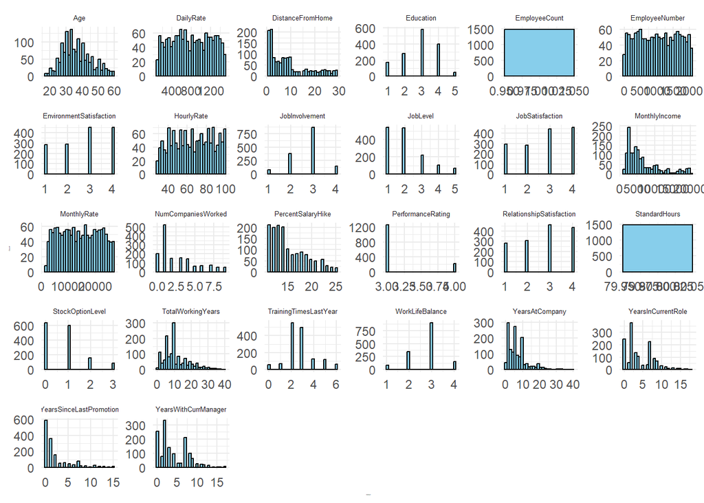

```r
# Filtern Sie die numerischen Spalten
numeric_columns <- HR_Analytics %>% select_if(is.numeric)

# Wandle den Datensatz in ein langes Format um
long_data <- numeric_columns %>% pivot_longer(everything(), names_to = "Variable", values_to = "Value")

# Erstelle ein Histogramm für jede Variable mit facet_wrap
ggplot(long_data, aes(x = Value)) +
  geom_histogram(bins = 30, fill = "skyblue", color = "black") +
  facet_wrap(~ Variable, scales = "free") +
  labs(x = "Value", y = "Count") +
  theme_minimal() +
  theme(strip.text = element_text(size = 5),
        axis.title.x = element_text(size = 1),
        axis.title.y = element_text(size = 1))
```

In diesen Histogrammen gibt es einiges zu sehen:

- Viele Histogramme sind rechtsschief. Für einige ML-Modelle wird hier ggf. eine Transformation erforderlich.
- Bei rechtsschiefen Histogrammen sind die meisten Werte relativ niedrig und es gibt einige höhere Ausreißerwerte.
- Viele ML-Modelle machen Annahmenüber die Verteilung der Daten, oft dass die Daten normalverteilt sind oder zumindest symmetrisch.  
  Eine schiefe Verteilung kann diese Annahmen verletzen und die Leistung des Modells beeinträchtigen.
- Die Skalierung der Merkmale kann auch beeinträchtigt werden.  
  In einer rechtsschiefen Verteilung könnten Ausreißer einen unverhältnismäßig großen Einfluss auf die Skalierung haben,  
  wodurch das Modell überempfindlich gegenüber diesen Ausreißern wird.
- Die Wertebereiche sind sehr unterschiedlich. Wir werden skalieren müssen.
- Die Überstunden (Overtime) sind nur mit ja oder nein angegeben worden.
- Alle Mitarbeiter arbeiten acht Stunden am Tag (StandardHours), was aber hier mit der Zahl 80 angegeben wurde.  
  Das muß korrigiert werden und auf 8 gesetzt werden.

Es wird ermittelt, wie viele Mitarbeiter Überstunden machen.

```r
# Zusammenfassungstabelle erstellen
overtime_count <- HR_Analytics %>%
  group_by(OverTime) %>%
  summarise(count = n())

print(overtime_count)
```

```
## # A tibble: 2 × 2
##   OverTime count
##   <chr>    <int>
## 1 No        1062
## 2 Yes        418
```

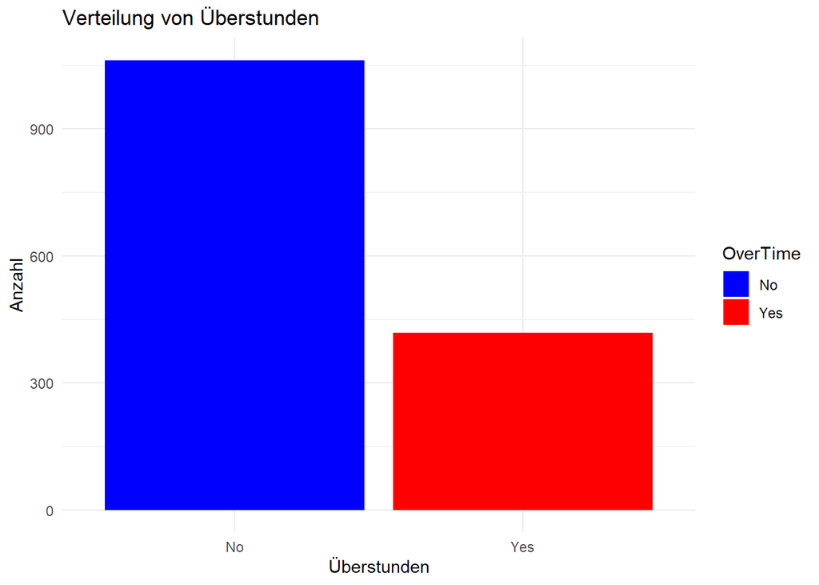

```r
# Säulendiagramm plotten
ggplot(overtime_count, aes(x = OverTime, y = count, fill = OverTime)) +
  geom_bar(stat = "identity") +
  scale_fill_manual(values = c("Yes" = "red", "No" = "blue")) +
  labs(title = "Verteilung von Überstunden",
       x = "Überstunden",
       y = "Anzahl") +
  theme_minimal()
```

```r
overtime_count
```

| OverTime | count |
| --- | --- |
| No | 1062 |
| Yes | 418 |

```r
#explore(HR_Analytics)
```

## 2 Daten aufbereiten

Da der Datensatz hier geändert wird, wird ein neuer Datensatz vorher erstellt, welcher “HR_Analytics_final” heißt.

```r
# Erstellen einer Kopie des HR_Analytics-Datensatzes
HR_Analytics_final <- HR_Analytics
```

Für die These 1 werden die relevanten Variablen in einen neuen Datensatz selektiert.

```r
# Erstellen Sie den neuen Dataframes
HR_Analytics_selected <- HR_Analytics %>%
  select(MonthlyIncome, HourlyRate, DailyRate, OverTime, WorkLifeBalance,
         EnvironmentSatisfaction, JobInvolvement, JobLevel,
         RelationshipSatisfaction, PerformanceRating,
         JobInvolvement, PercentSalaryHike, JobSatisfaction)
```

```r
view(HR_Analytics_selected)
```

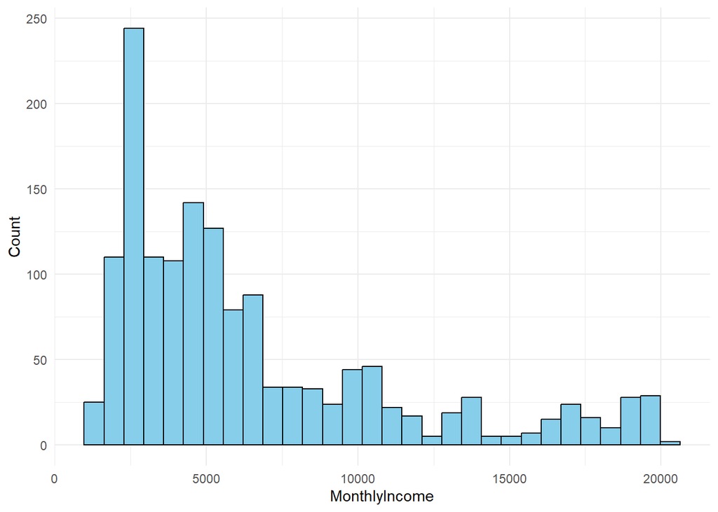

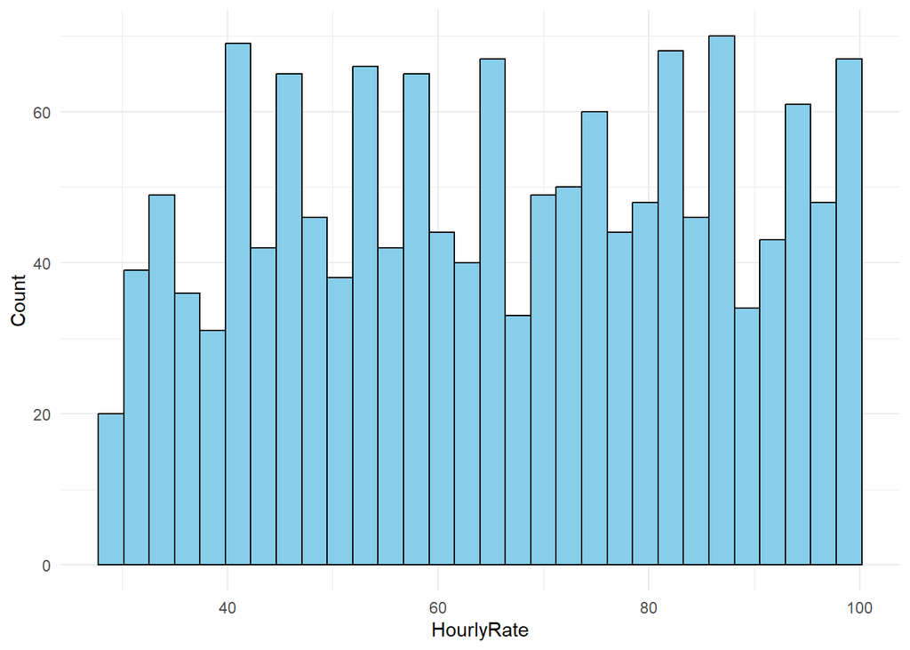

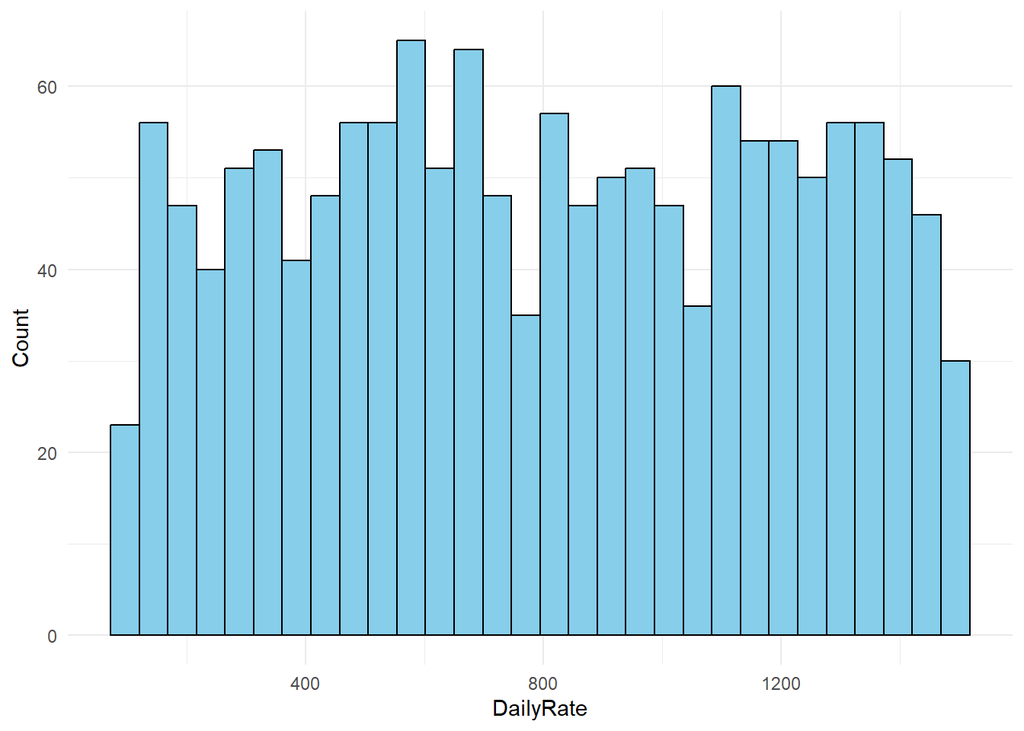

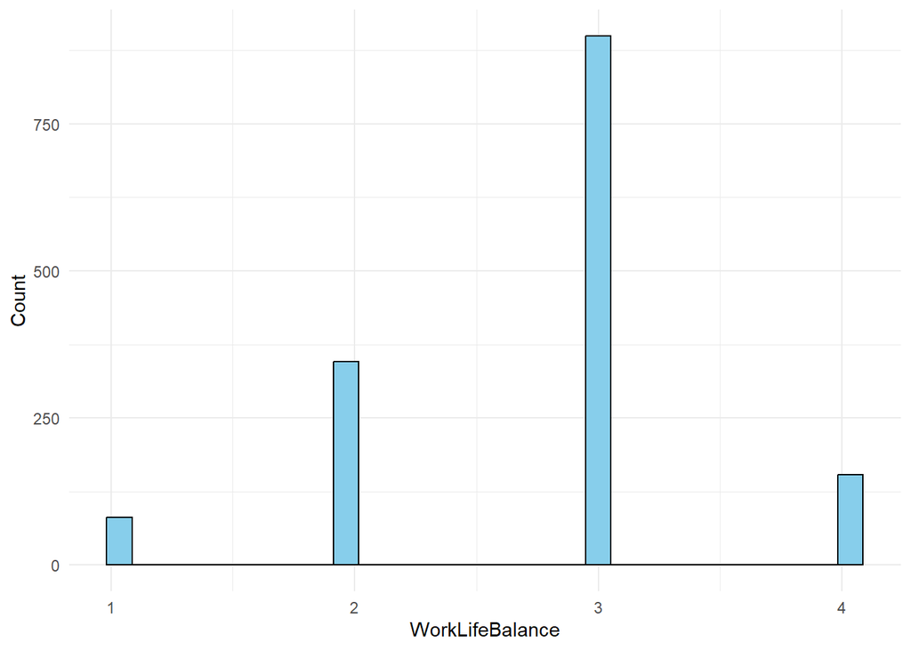

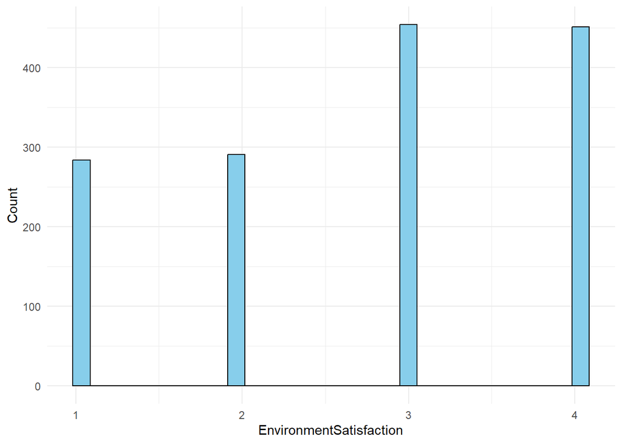

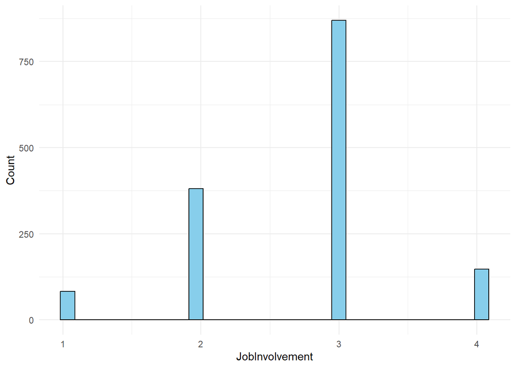

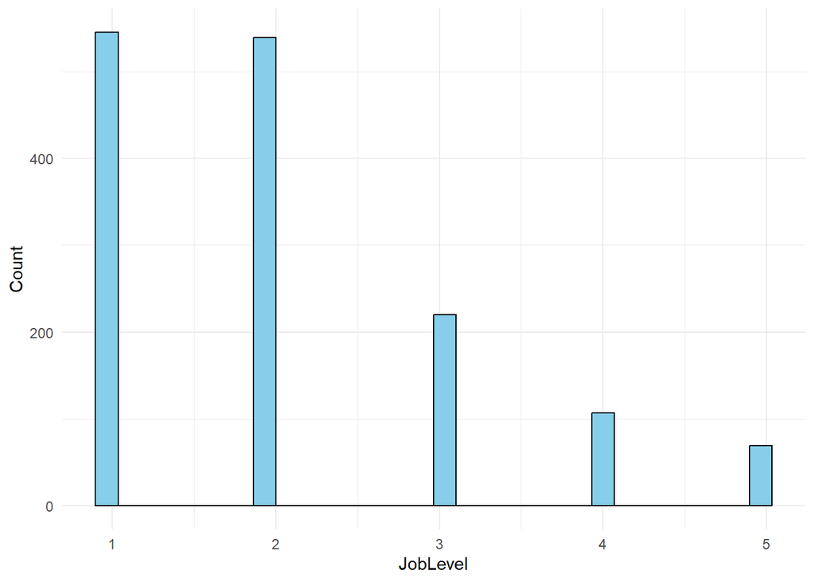

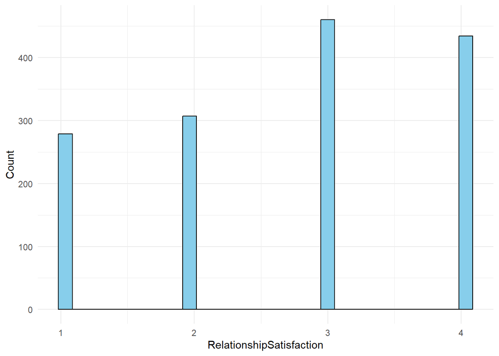

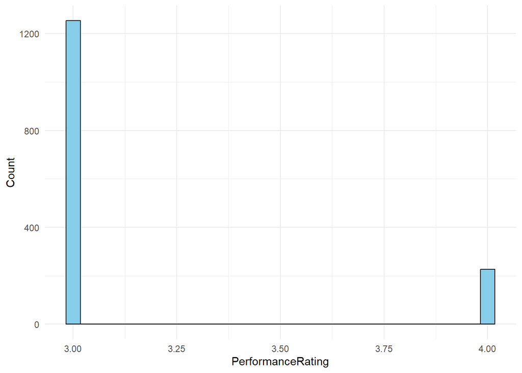

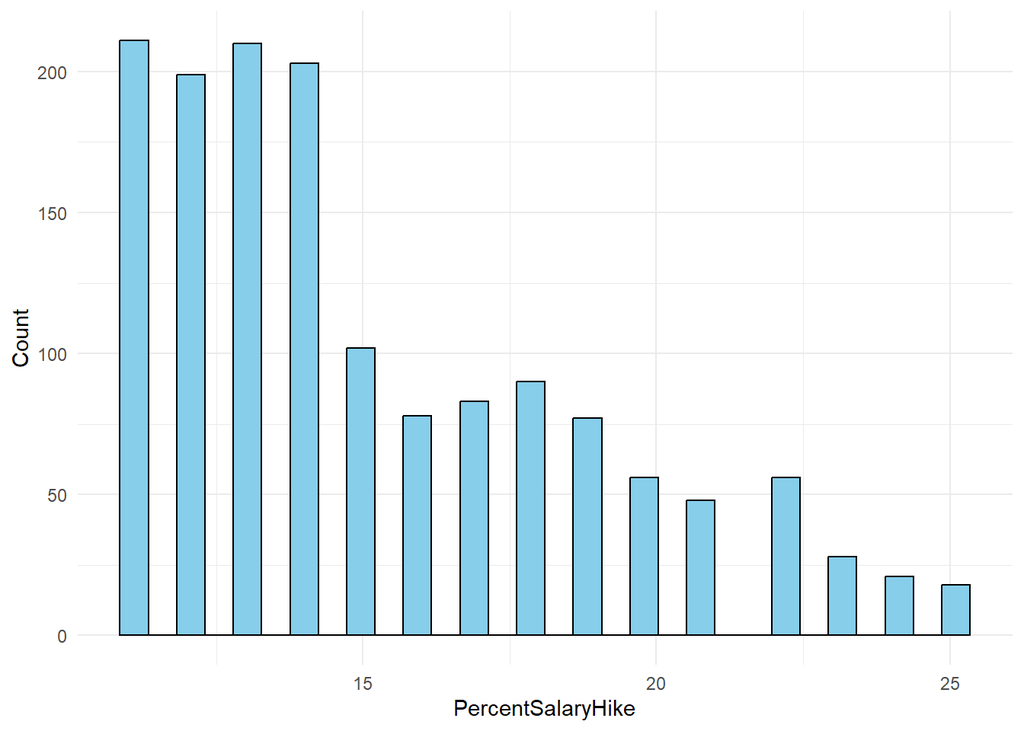

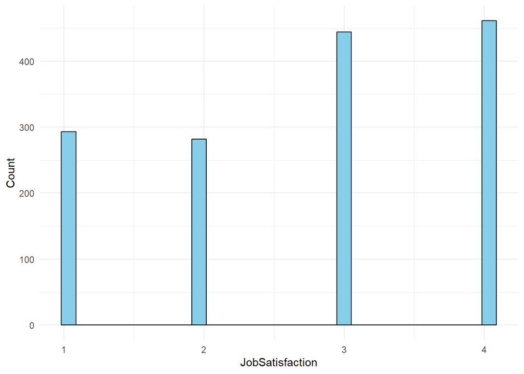

```r
# Für jede Variable im Datensatz erstellen Sie ein Histogramm
for (var in names(HR_Analytics_selected)) {
  # Überspringen Sie nicht-numerische Variablen
  if(is.numeric(HR_Analytics_selected[[var]])) {
    print(
      ggplot(HR_Analytics_selected, aes(!!sym(var))) +
      geom_histogram(bins = 30, fill = "skyblue", color = "black") +
      labs(x = var, y = "Count") +
      theme_minimal()
    )
  }
}
```

Vorab wird ein Testdatensatz erstellt.

### 2.1 Erstelle einen Testdatensatz

Zuerst wird ein Testdatensatz mit dem vermeidlich signifikantesten Zusammenhang erstellt. Der Testdatensatz soll den Datensatz “HR_Analytics” auf Robustheit von Analysen und Modellen testen. Damit kann man sicherstellen, dass der Code unter diesen spezifischen Bedingungen korrekt funktioniert. Der Testdatensatz soll sich auf das Monatliche Gehalt konzentrieren. Das kann wertvolle Einblicke in den spezifischen Zusammenhang zwischen Gehalt und Jobzufriedenheit im Datensatz geben und die These stützen.

Der “MonthlyIncome” wird in vier gleiche Intervalle eingeteilt:

Die Intervalle wurden berechnet, indem der gesamte Bereich der Gehälter von 1009 bis 19999 in vier gleich große Teile aufgeteilt wurde. Der Code benutzt die cut-Funktion, um die “MonthlyIncome”-Werte in diese vier Kategorien einzuteilen. Dabei wird das erste Intervall einschließlich des untersten Werts definiert (include.lowest = TRUE).

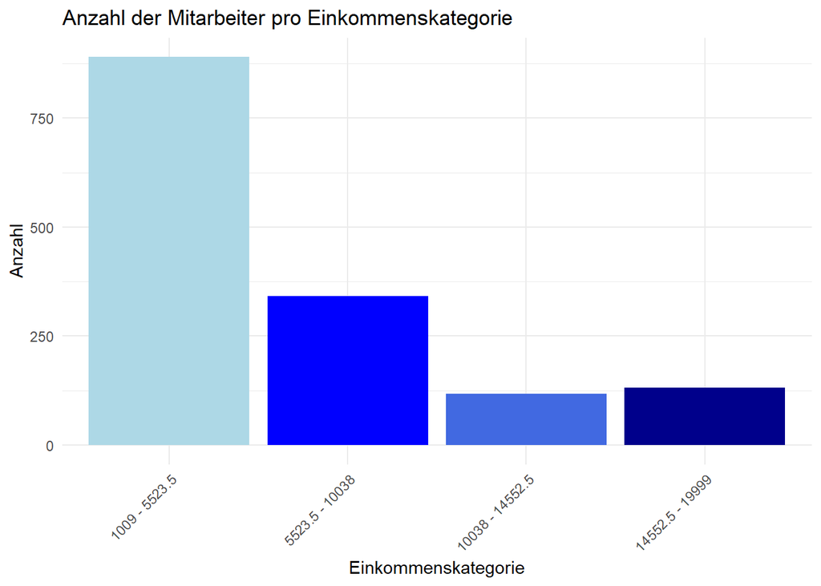

```r
# Definieren der Intervalle
intervals <- 4
range_width <- (19999 - 1009) / intervals
breaks <- seq(1009, 19999, by = range_width)

# Zuordnung der Intervalle zur IncomeCategory Variable
HR_Analytics_final$IncomeCategory <- cut(HR_Analytics_final$MonthlyIncome, breaks = breaks, include.lowest = TRUE)

# Definieren der Labels für die Achse
income_labels <- c("1009 - 5523.5", "5523.5 - 10038", "10038 - 14552.5", "14552.5 - 19999")

# Zuordnung der Labels zur IncomeCategory Variable
HR_Analytics_final$IncomeLabel <- factor(HR_Analytics_final$IncomeCategory, labels = income_labels)

# Erstellen des Plots
ggplot(HR_Analytics_final, aes(x = IncomeLabel)) +
  geom_bar(fill = c("lightblue", "blue", "royalblue", "darkblue")) +
  labs(title = "Anzahl der Mitarbeiter pro Einkommenskategorie",
       x = "Einkommenskategorie",
       y = "Anzahl") +
  theme_minimal() +
  theme(axis.text.x = element_text(angle = 45, hjust = 1)) # Drehen der x-Achsen-Labels für bessere Lesbarkeit
```

Eine stratifizierte Stichprobe ist in diesem Zusammenhang durchaus sinnvoll sein, besonders wenn Sie eine repräsentative Analyse durchführt, oder wenn es erhebliche Unterschiede in der Verteilung der Gehaltsintervalle oder der Jobzufriedenheitskategorien in der Gesamtbevölkerung gibt.

Eine stratifizierte Stichprobe bedeutet, dass Sie aus jeder Kategorie (z.B. Gehaltsintervall oder Jobzufriedenheitsstufe) eine proportionale Anzahl von Beobachtungen auswählen. Dies stellt sicher, dass Ihre Stichprobe die Gesamtpopulation in Bezug auf die kategorialen Variablen genau widerspiegelt.

```r
selected_columns <- data.frame(
  EmpID = HR_Analytics_final$EmpID,
  IncomeLabel = HR_Analytics_final$IncomeLabel,
  JobSatisfaction = HR_Analytics_final$JobSatisfaction
)

# Um die ersten paar Zeilen der Tabelle anzuzeigen
head(selected_columns)
```

|  | EmpID | IncomeLabel | JobSatisfaction |
| --- | --- | --- | --- |
| 1 | RM297 | 1009 - 5523.5 | 3 |
| 2 | RM302 | 1009 - 5523.5 | 3 |
| 3 | RM458 | 1009 - 5523.5 | 2 |
| 4 | RM728 | 1009 - 5523.5 | 4 |
| 5 | RM829 | 1009 - 5523.5 | 3 |
| 6 | RM973 | 1009 - 5523.5 | 4 |

Eine stratifizierte Stichprobe ist eine Methode, bei der die Population in verschiedene Strata oder Gruppen unterteilt wird, und dann werden aus jedem Stratum zufällige Stichproben gezogen. Diese Methode kann nützlich sein, wenn Sie sicherstellen möchten, dass die Stichprobe alle Ebenen oder Kategorien einer bestimmten Variable repräsentiert.

Wenn Sie eine stratifizierte Stichprobe aus der Tabelle selected_columns auf der Grundlage von IncomeLabel erstellen möchten, könnte dies sinnvoll sein, wenn Sie sicherstellen möchten, dass die Stichprobe alle Einkommenskategorien repräsentiert. Dies kann besonders nützlich sein, wenn Sie die Beziehung zwischen Einkommen und Arbeitszufriedenheit untersuchen möchten.

Hier ist ein Beispiel, wie Sie eine stratifizierte Stichprobe mit der caret-Bibliothek erstellen können, wobei 70% der Daten für das Training verwendet werden:

```r
# Erstellen einer 70-30-Aufteilung für Training und Test, stratifiziert nach IncomeLabel
splitIndex <- createDataPartition(selected_columns$IncomeLabel, p = .7, list = FALSE, times = 1)

# Teilen Sie die Daten entsprechend auf
trainData <- selected_columns[splitIndex, ]
testData <- selected_columns[-splitIndex, ]
```

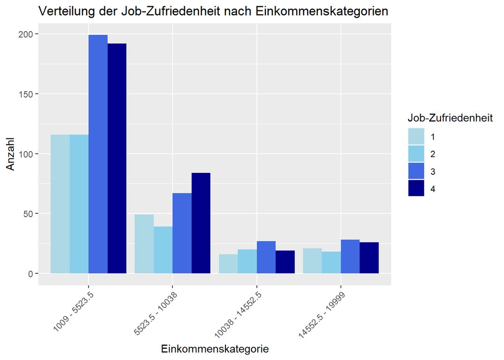

```r
ggplot(trainData, aes(x = IncomeLabel, fill = as.factor(JobSatisfaction))) +
  geom_bar(position = "dodge") +
  scale_fill_manual(values = c("lightblue", "skyblue", "royalblue", "darkblue")) +
  labs(
    x = "Einkommenskategorie",
    y = "Anzahl",
    fill = "Job-Zufriedenheit",
    title = "Verteilung der Job-Zufriedenheit nach Einkommenskategorien"
  ) +
  theme(axis.text.x = element_text(angle = 45, hjust = 1))
```

### 2.2 Fehlende Daten

Die meisten ML-Modelle können mit fehlenden Daten nicht umgehen. Wir haben gesehen, dass es nur bei der Variable “YearsWithCurrManager” 57 NA-Eintrage gibt. Wir ersetzen diese WErte mit dem Median.

```r
# Berechnen des Medians für die Spalte YearsWithCurrManager, ohne NA-Werte zu berücksichtigen
median_YearsWithCurrManager <- median(HR_Analytics_final$YearsWithCurrManager, na.rm = TRUE)

# Ersetzen der NA-Werte in der Spalte YearsWithCurrManager durch den berechneten Median
HR_Analytics_final$YearsWithCurrManager[is.na(HR_Analytics_final$YearsWithCurrManager)] <- median_YearsWithCurrManager
```

- Alle fehlenden Werte in der Variable “YearsWithCurrManager” werden durch den Median dieser Variablen ersetzt.

```r
summary(HR_Analytics_final)
```

```
##     EmpID                Age          AgeGroup          Attrition
##  Length:1480        Min.   :18.00   Length:1480        Length:1480
##  Class :character   1st Qu.:30.00   Class :character   Class :character
##  Mode  :character   Median :36.00   Mode  :character   Mode  :character
##                     Mean   :36.92
##                     3rd Qu.:43.00
##                     Max.   :60.00
##  BusinessTravel       DailyRate       Department        DistanceFromHome
##  Length:1480        Min.   : 102.0   Length:1480        Min.   : 1.00
##  Class :character   1st Qu.: 465.0   Class :character   1st Qu.: 2.00
##  Mode  :character   Median : 800.0   Mode  :character   Median : 7.00
##                     Mean   : 801.4                      Mean   : 9.22
##                     3rd Qu.:1157.0                      3rd Qu.:14.00
##                     Max.   :1499.0                      Max.   :29.00
##    Education     EducationField     EmployeeCount EmployeeNumber
##  Min.   :1.000   Length:1480        Min.   :1     Min.   :   1.0
##  1st Qu.:2.000   Class :character   1st Qu.:1     1st Qu.: 493.8
##  Median :3.000   Mode  :character   Median :1     Median :1027.5
##  Mean   :2.911                      Mean   :1     Mean   :1031.9
##  3rd Qu.:4.000                      3rd Qu.:1     3rd Qu.:1568.2
##  Max.   :5.000                      Max.   :1     Max.   :2068.0
##  EnvironmentSatisfaction    Gender            HourlyRate     JobInvolvement
##  Min.   :1.000           Length:1480        Min.   : 30.00   Min.   :1.00
##  1st Qu.:2.000           Class :character   1st Qu.: 48.00   1st Qu.:2.00
##  Median :3.000           Mode  :character   Median : 66.00   Median :3.00
##  Mean   :2.724                              Mean   : 65.85   Mean   :2.73
##  3rd Qu.:4.000                              3rd Qu.: 83.00   3rd Qu.:3.00
##  Max.   :4.000                              Max.   :100.00   Max.   :4.00
##     JobLevel       JobRole          JobSatisfaction MaritalStatus
##  Min.   :1.000   Length:1480        Min.   :1.000   Length:1480
##  1st Qu.:1.000   Class :character   1st Qu.:2.000   Class :character
##  Median :2.000   Mode  :character   Median :3.000   Mode  :character
##  Mean   :2.065                      Mean   :2.725
##  3rd Qu.:3.000                      3rd Qu.:4.000
##  Max.   :5.000                      Max.   :4.000
##  MonthlyIncome    SalarySlab         MonthlyRate    NumCompaniesWorked
##  Min.   : 1009   Length:1480        Min.   : 2094   Min.   :0.000
##  1st Qu.: 2922   Class :character   1st Qu.: 8051   1st Qu.:1.000
##  Median : 4933   Mode  :character   Median :14220   Median :2.000
##  Mean   : 6505                      Mean   :14298   Mean   :2.687
```

[output cut: 22 more lines]

```
##  Max.   :6.000         Max.   :4.000   Max.   :40.000   Max.   :18.000
##  YearsSinceLastPromotion YearsWithCurrManager             IncomeCategory
##  Min.   : 0.000          Min.   : 0.000       [1.01e+03,5.76e+03]:890
##  1st Qu.: 0.000          1st Qu.: 2.000       (5.76e+03,1.05e+04]:341
##  Median : 1.000          Median : 3.000       (1.05e+04,1.53e+04]:117
##  Mean   : 2.182          Mean   : 4.075       (1.53e+04,2e+04]   :132
##  3rd Qu.: 3.000          3rd Qu.: 7.000
##  Max.   :15.000          Max.   :17.000
##           IncomeLabel
##  1009 - 5523.5  :890
##  5523.5 - 10038 :341
##  10038 - 14552.5:117
##  14552.5 - 19999:132
##
##
```

### 2.3 Kategorische Daten

Untersucht wird der Dataframe HR_Analytics_final. Dieser wird nach kategorischen Daten untersucht.

```r
# Identifizieren der kategorischen Variablen (ausschließen der numerischen)
categorical_vars <- names(HR_Analytics_final)[sapply(HR_Analytics_final, function(x) !is.numeric(x))]

# Anzeigen der kategorischen Variablen
categorical_vars
```

```
##  [1] "EmpID"          "AgeGroup"       "Attrition"      "BusinessTravel"
##  [5] "Department"     "EducationField" "Gender"         "JobRole"
##  [9] "MaritalStatus"  "SalarySlab"     "Over18"         "OverTime"
## [13] "IncomeCategory" "IncomeLabel"
```

Die EmpID ist eine eindeutige Kennung für jeden Mitarbeiter. Es ist nicht sinnvoll, diese in der Analyse zu verwenden,  
da sie wahrscheinlich keine nützlichen Informationen enthält.

```r
# Erstellen eines Vektors, der die Zuordnung der Altersgruppen zu den numerischen Werten definiert
age_mapping <- c("18-25" = 1, "26-35" = 2, "36-45" = 3, "46-55" = 4, "55+" = 5)

# Anwendung der Zuordnung auf die "AgeGroup"-Spalte
HR_Analytics_final$AgeGroup <- age_mapping[HR_Analytics_final$AgeGroup]
```

Dann wird die Einzigartigkeit der Spalte angeschaut, um sicherzustellen, das sie genau den angegebenen Ebenen entspricht.

```r
unique(HR_Analytics_final$AgeGroup)
```

```
## [1] 1 2 3 4 5
```

Attrition: Da es sich um eine binäre Variable handelt, kannst du sie in 0 und 1 umwandeln, wobei Yes durch 1 und No durch 0 ersetzt wird.

```r
HR_Analytics_final$Attrition <- ifelse(HR_Analytics_final$Attrition == "Yes", 1, 0)
```

Over18: Da alle Werte Y sind, kann diese Spalte möglicherweise entfernt werden, da sie keine nützliche Information enthält. Wenn du sie jedoch als numerische Variable behalten möchtest, kannst du sie in 1 umwandeln.

```r
HR_Analytics_final$Over18 <- 1
```

Gender: Du kannst diese Spalte in eine binäre Variable umwandeln, indem du Male durch 1 und Female durch 0 ersetzt.

```r
HR_Analytics_final$Gender <- ifelse(HR_Analytics_final$Gender == "Male", 1, 0)
```

MaritalStatus: Da es sich um eine kategoriale Variable mit drei Werten handelt, kannst du sie in numerische Werte umwandeln,  
z. B. Single als 1, Married als 2 und Divorced als 3.

```r
MaritalStatus_mapping <- c('Single' = 1, 'Married' = 2, 'Divorced' = 3)
HR_Analytics_final$MaritalStatus <- MaritalStatus_mapping[HR_Analytics_final$MaritalStatus]
```

Die Variable “OverTime” in unserem Datensatz ist eine Zeichenkette, welche die Werte “Yes” oder “No” enthält.  
Deshalb möchten wir diese Werte in nominale Werte umwandeln. Yes steht dabei für 1 und No für 0.

```r
# Umwandlung der Overtime-Variable in eine nominale Variable (1 für "Yes" und 0 für "No")
HR_Analytics_final$OverTime <- ifelse(HR_Analytics_final$OverTime == "Yes", 1, 0)
```

```r
head(HR_Analytics_final)
```

| EmpID | Age | AgeGroup | Attrition | BusinessTravel | DailyRate | Department | DistanceFromHome | Education | EducationField | EmployeeCount | EmployeeNumber | EnvironmentSatisfaction | Gender | HourlyRate | JobInvolvement | JobLevel | JobRole | JobSatisfaction | MaritalStatus | MonthlyIncome | SalarySlab | MonthlyRate | NumCompaniesWorked | Over18 | OverTime | PercentSalaryHike | PerformanceRating | RelationshipSatisfaction | StandardHours | … |
| --- | --- | --- | --- | --- | --- | --- | --- | --- | --- | --- | --- | --- | --- | --- | --- | --- | --- | --- | --- | --- | --- | --- | --- | --- | --- | --- | --- | --- | --- | --- |
| RM297 | 18 | 1 | 1 | Travel_Rarely | 230 | Research & Development | 3 | 3 | Life Sciences | 1 | 405 | 3 | 1 | 54 | 3 | 1 | Laboratory Technician | 3 | 1 | 1420 | Upto 5k | 25233 | 1 | 1 | 0 | 13 | 3 | 3 | 80 | … |
| RM302 | 18 | 1 | 0 | Travel_Rarely | 812 | Sales | 10 | 3 | Medical | 1 | 411 | 4 | 0 | 69 | 2 | 1 | Sales Representative | 3 | 1 | 1200 | Upto 5k | 9724 | 1 | 1 | 0 | 12 | 3 | 1 | 80 | … |
| RM458 | 18 | 1 | 1 | Travel_Frequently | 1306 | Sales | 5 | 3 | Marketing | 1 | 614 | 2 | 1 | 69 | 3 | 1 | Sales Representative | 2 | 1 | 1878 | Upto 5k | 8059 | 1 | 1 | 1 | 14 | 3 | 4 | 80 | … |
| RM728 | 18 | 1 | 0 | Non-Travel | 287 | Research & Development | 5 | 2 | Life Sciences | 1 | 1012 | 2 | 1 | 73 | 3 | 1 | Research Scientist | 4 | 1 | 1051 | Upto 5k | 13493 | 1 | 1 | 0 | 15 | 3 | 4 | 80 | … |
| RM829 | 18 | 1 | 1 | Non-Travel | 247 | Research & Development | 8 | 1 | Medical | 1 | 1156 | 3 | 1 | 80 | 3 | 1 | Laboratory Technician | 3 | 1 | 1904 | Upto 5k | 13556 | 1 | 1 | 0 | 12 | 3 | 4 | 80 | … |
| RM973 | 18 | 1 | 0 | Non-Travel | 1124 | Research & Development | 1 | 3 | Life Sciences | 1 | 1368 | 4 | 0 | 97 | 3 | 1 | Laboratory Technician | 4 | 1 | 1611 | Upto 5k | 19305 | 1 | 1 | 0 | 15 | 3 | 3 | 80 | … |

Es wird ein neuer Datensatz erstellt, welcher die gewünschten Variablen enthält:

```r
HR_Analytics_thesis1 <- HR_Analytics_final %>%
  select(MonthlyIncome, HourlyRate, DailyRate, OverTime, WorkLifeBalance,
         EnvironmentSatisfaction, JobInvolvement, JobLevel,
         RelationshipSatisfaction, PerformanceRating, PercentSalaryHike)

head(HR_Analytics_thesis1)
```

| MonthlyIncome | HourlyRate | DailyRate | OverTime | WorkLifeBalance | EnvironmentSatisfaction | JobInvolvement | JobLevel | RelationshipSatisfaction | PerformanceRating | PercentSalaryHike |
| --- | --- | --- | --- | --- | --- | --- | --- | --- | --- | --- |
| 1420 | 54 | 230 | 0 | 3 | 3 | 3 | 1 | 3 | 3 | 13 |
| 1200 | 69 | 812 | 0 | 3 | 4 | 2 | 1 | 1 | 3 | 12 |
| 1878 | 69 | 1306 | 1 | 3 | 2 | 3 | 1 | 4 | 3 | 14 |
| 1051 | 73 | 287 | 0 | 3 | 2 | 3 | 1 | 4 | 3 | 15 |
| 1904 | 80 | 247 | 0 | 3 | 3 | 3 | 1 | 4 | 3 | 12 |
| 1611 | 97 | 1124 | 0 | 4 | 4 | 3 | 1 | 3 | 3 | 15 |